# R Basics - A simple data analysis project

Kristen Sosulski

May 10, 2017

Updated on Wed May 10 18:33:31 2017.

This section will guide you in the process of decoding your data into information and ultimately intelligible insights. In doing so, we will explore the use of tidyverse and R base packages.

## When working with a new data what initial questions do you have?

Consider the following questions to guide your understanding.

- What does your data represent in the real world?
- How is this real world phenomena characterized by the data that you have?
- From what time period is the data?

Once you have this basic understanding of your data you can dig deeper. Then you can use visualization techniques to explore your data and derive some basic understandings of the phenomena you are studying, such as the largest and smallest values for each variable. In addition, calculating summary statistics translate data into information by revealing the shape of the data, the mean, median, minimum value, maximum value, and variability all with simple visualizations.

For any data science project there are few simple steps to follow.

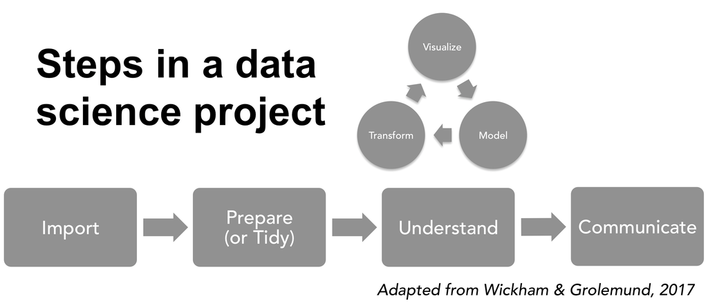

## Exercise A: Importing your data

Using the World internet usage data we will compare of read.csv to read_csv for importing data.

#### utils package using read.csv()

```r
internet_utils <- read.csv("world_internet_usage.csv")
head(internet_utils)
```

```
##                country X2000 X2001 X2002 X2003 X2004 X2005 X2006 X2007
## 1                China  1.78  2.64  4.60  6.20  7.30  8.52 10.52 16.00
## 2               Mexico  5.08  7.04 11.90 12.90 14.10 17.21 19.52 20.81
## 3               Panama  6.55  7.27  8.52  9.99 11.14 11.48 17.35 22.29
## 4              Senegal  0.40  0.98  1.01  2.10  4.39  4.79  5.61  7.70
## 5            Singapore 36.00 41.67 47.00 53.84 62.00 61.00 59.00 69.90
## 6 United Arab Emirates 23.63 26.27 28.32 29.48 30.13 40.00 52.00 61.00
##   X2008 X2009 X2010 X2011 X2012
## 1 22.60 28.90 34.30 38.30 42.30
## 2 21.71 26.34 31.05 34.96 38.42
## 3 33.82 39.08 40.10 42.70 45.20
## 4 10.60 14.50 16.00 17.50 19.20
## 5 69.00 69.00 71.00 71.00 74.18
## 6 63.00 64.00 68.00 78.00 85.00
```

#### readr read_csv using read_csv()

```r
library(readr)
internet_readr <- read_csv("world_internet_usage.csv")
head(internet_readr)
```

```
## # A tibble: 6 × 14
##                country `2000` `2001` `2002` `2003` `2004` `2005` `2006`
##                  <chr>  <dbl>  <dbl>  <dbl>  <dbl>  <dbl>  <dbl>  <dbl>
## 1                China   1.78   2.64   4.60   6.20   7.30   8.52  10.52
## 2               Mexico   5.08   7.04  11.90  12.90  14.10  17.21  19.52
## 3               Panama   6.55   7.27   8.52   9.99  11.14  11.48  17.35
## 4              Senegal   0.40   0.98   1.01   2.10   4.39   4.79   5.61
## 5            Singapore  36.00  41.67  47.00  53.84  62.00  61.00  59.00
## 6 United Arab Emirates  23.63  26.27  28.32  29.48  30.13  40.00  52.00
## # ... with 6 more variables: `2007` <dbl>, `2008` <dbl>, `2009` <dbl>,
## #   `2010` <dbl>, `2011` <dbl>, `2012` <dbl>
```

### Accessing specific rows and columns

```r
#extract by position
internet_readr[[2,1]]
```

```
## [1] "Mexico"
```

```r
internet_utils [2,1] # double [[ ]] works too
```

```
## [1] Mexico
## 7 Levels: China Mexico Panama Senegal Singapore ... United States
```

```r
#extract by name
internet_readr$country
```

```
## [1] "China"                "Mexico"               "Panama"
## [4] "Senegal"              "Singapore"            "United Arab Emirates"
## [7] "United States"
```

```r
internet_utils$country
```

```
## [1] China                Mexico               Panama
## [4] Senegal              Singapore            United Arab Emirates
## [7] United States
## 7 Levels: China Mexico Panama Senegal Singapore ... United States
```

```r
#to use with infix function add a .
internet_readr %>% .$country
```

```
## [1] "China"                "Mexico"               "Panama"
## [4] "Senegal"              "Singapore"            "United Arab Emirates"
## [7] "United States"
```

## Exercise B) Tidy data - reshaping

You need to rename columns first to remove the X in front of each year.

```r
names(internet_utils) <-c("country", "2000", "2001", "2002", "2003", "2004", "2005", "2006", "2007", "2008", "2009", "2010", "2011", "2012")
names(internet_utils)
```

```
##  [1] "country" "2000"    "2001"    "2002"    "2003"    "2004"    "2005"
##  [8] "2006"    "2007"    "2008"    "2009"    "2010"    "2011"    "2012"
```

Reshape a data frame

```r
library(reshape2)
internet_utils_reshaped <- melt(internet_utils,id.vars="country", variable.name="year", value.name="usage")
#View(internet_utils_reshaped)
```

Reshape a tibble

```r
internet_readr_reshaped <- melt(internet_readr,id.vars="country", variable.name="year", value.name="usage")
internet_readr_reshaped
```

```
##                 country year usage
## 1                 China 2000  1.78
## 2                Mexico 2000  5.08
## 3                Panama 2000  6.55
## 4               Senegal 2000  0.40
## 5             Singapore 2000 36.00
## 6  United Arab Emirates 2000 23.63
## 7         United States 2000 43.08
## 8                 China 2001  2.64
## 9                Mexico 2001  7.04
## 10               Panama 2001  7.27
## 11              Senegal 2001  0.98
## 12            Singapore 2001 41.67
## 13 United Arab Emirates 2001 26.27
## 14        United States 2001 49.08
```

[output cut: 77 more lines]

```r
class(internet_readr_reshaped) # turns into a data.frame!
```

```
## [1] "data.frame"
```

Use the gather function to reshape

```r
tidy_internet_readr <-
internet_readr %>%
gather(`2000`,`2001`,`2002`,`2003`,`2004`,`2005`,`2006`,`2007`,`2008`,`2009`,`2010`,`2011`,`2012`, key="year", value="usage")

tidy_internet_readr
```

```
## # A tibble: 91 × 3
##                 country  year usage
##                   <chr> <chr> <dbl>
## 1                 China  2000  1.78
## 2                Mexico  2000  5.08
## 3                Panama  2000  6.55
## 4               Senegal  2000  0.40
## 5             Singapore  2000 36.00
## 6  United Arab Emirates  2000 23.63
## 7         United States  2000 43.08
## 8                 China  2001  2.64
## 9                Mexico  2001  7.04
## 10               Panama  2001  7.27
## # ... with 81 more rows
```

## Exercise C) Understand - Visualize

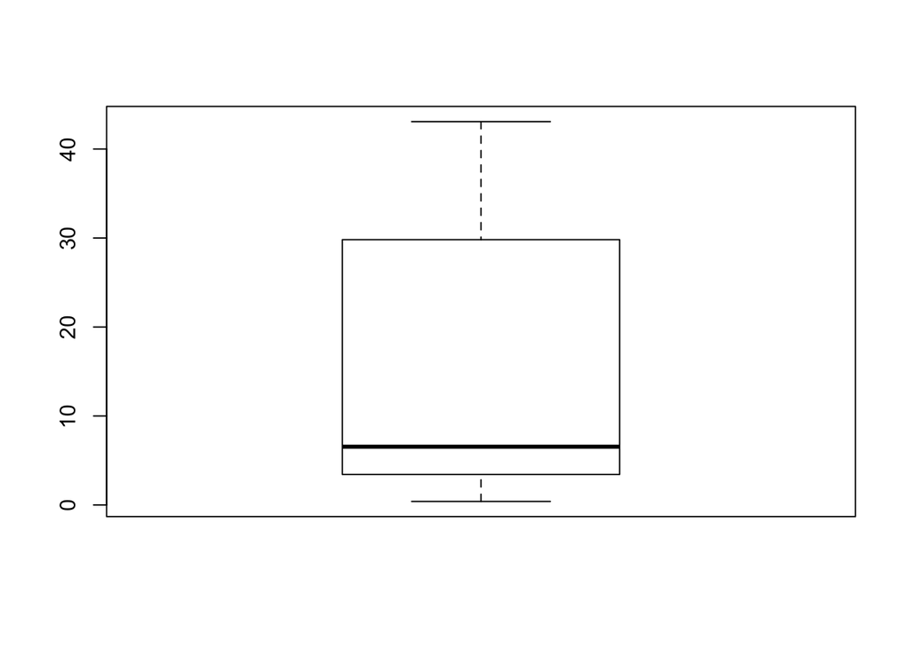

```r
#single boxplot
boxplot(internet_readr$`2000`)
```

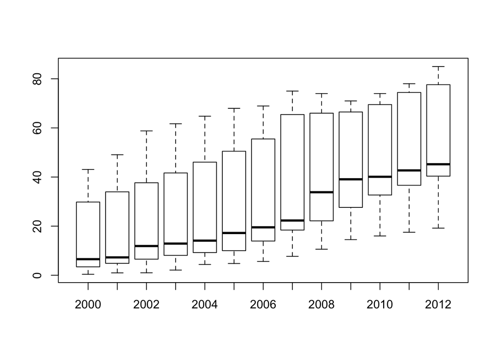

```r
#multiple box plots
boxplot(internet_readr[,2:14])
```

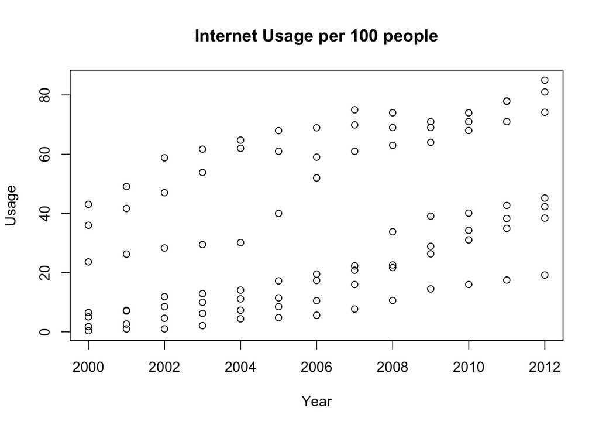

```r
#simple plot
plot(tidy_internet_readr$year,tidy_internet_readr$usage,main="Internet Usage per 100 people",xlab="Year", ylab="Usage")
```

## Exercise D) Communicate

Create charts and reports.

### Create presentation ready charts and graphs using ggplot and ggthemes.

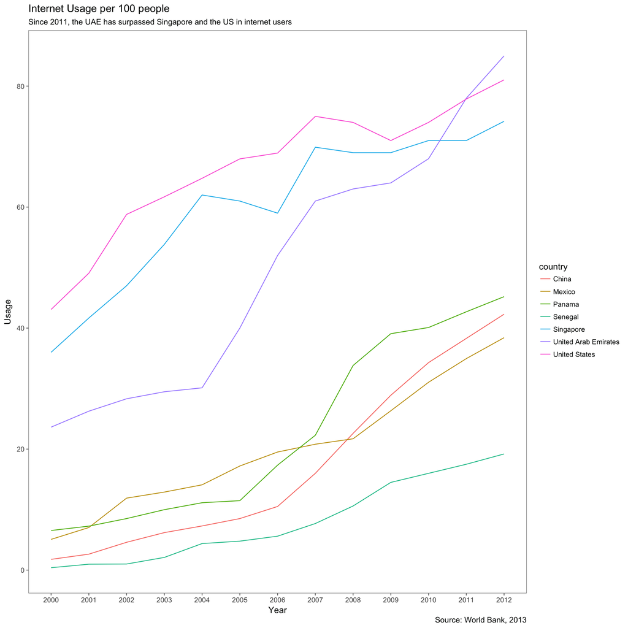

```r
#scatter plot
library(ggthemes)
library(ggplot2)
ggplot(tidy_internet_readr,aes(x=year,y=usage,colour=country,group=country)) + geom_line() + labs(title = "Internet Usage per 100 people", subtitle = "Since 2011, the UAE has surpassed Singapore and the US in internet users", caption = "Source: World Bank, 2013",x = "Year",y ="Usage") + theme_few()
```

### Create a markdown document